# My Example Report

# My Example Report

#### Report reference: EG.001

#### Report creation date-time: 17/11/2023, 00:18 AM

#### Data cutoff date-time: 30/09/2022, 23:59 PM

### Notes:

A key explaining how to read the icons for Variation, Assurance, and Data Quality is at the bottom of this document.

### Domain 1

Varia-tion

Assur-ance

Data Quality

**Updated to 02-Aug-2020 Target Set by Actual 222 Neutral**

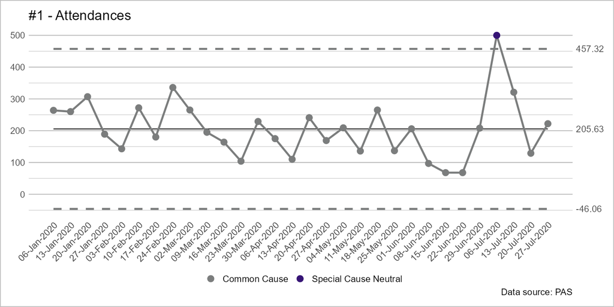

Data Owner: Central Information Team

**Updated to 02-Aug-2020 Target ≤ 69.7% Set by NHSE Actual 73%**

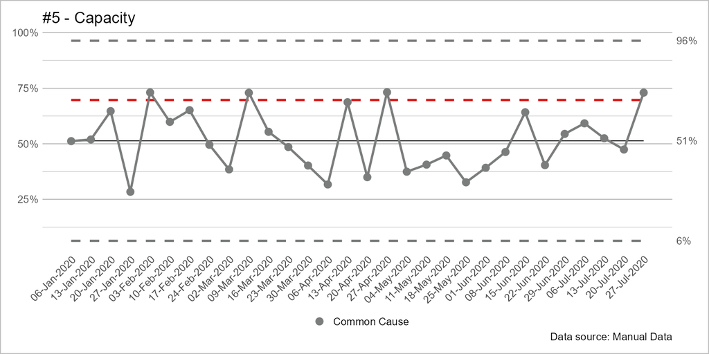

Accountable Person: Hannah Harvey (Service GM)

Data Owner: Divisional Information Team

**Updated to 02-Aug-2020 Target ≥ 0.71 Set by Trust Actual 0.46**

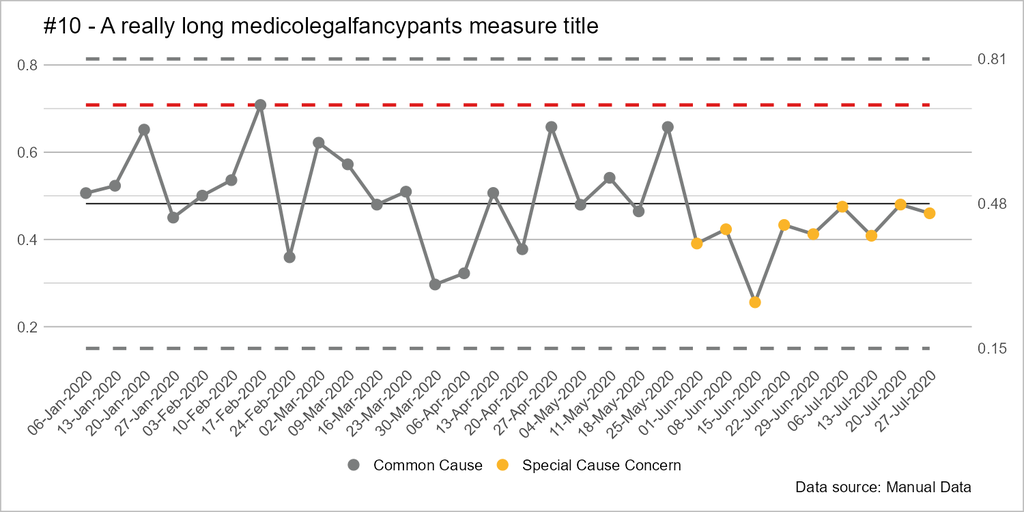

Accountable Person: Hannah Harvey (Service GM)

Data Owner: Divisional Information Team

### Area 2

Varia-tion

Assur-ance

Data Quality

**Updated to 30-Sep-2022 Target Set by Trust Actual 0.38 No target**

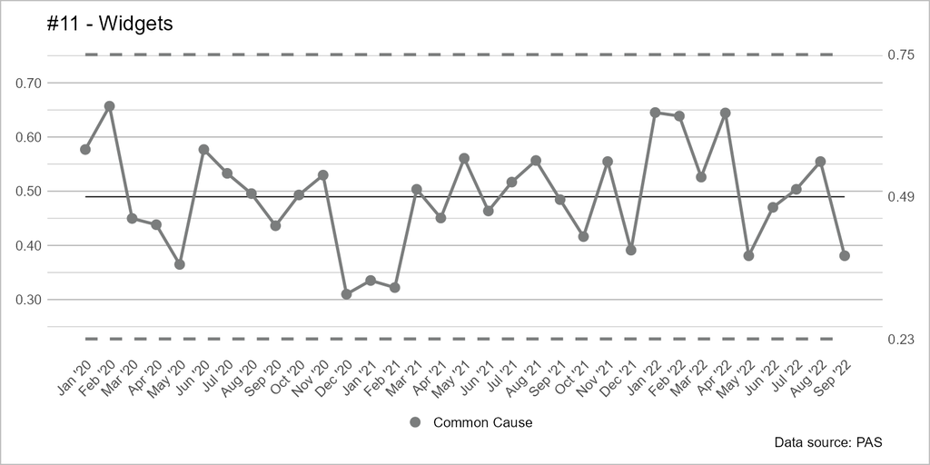

Accountable Person: Tony Smith (Divisional Governance)

Data Owner: Divisional Information Team

**Updated to 02-Aug-2020 Target ≥ 90% Set by Division Actual 47%**

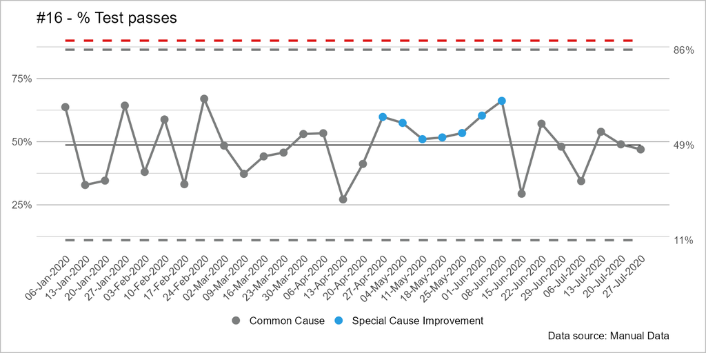

Accountable Person: Sally Fenwick (Divisional HR)

Data Owner: Corporate HR

### Zone 3

Varia-tion

Assur-ance

Data Quality

**Updated to 02-Aug-2020 Target ≥ 0.49 Set by Trust Actual 0.63**

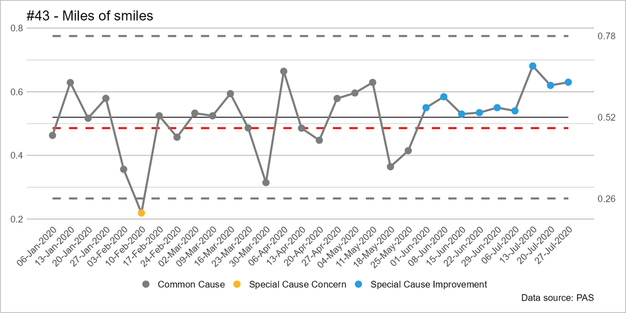

Accountable Person: Hannah Harvey (Service GM)

Data Owner: Central Information Team

**Updated to 30-Sep-2022 Target Set by Actual 97 Neutral**

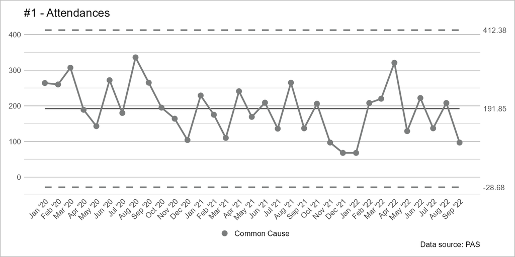

Data Owner: Central Information Team

#### SPC Variation Icons

Used to summarise the type of variation seen in the most recent data point of a given measure.

Icons

Variation Type

The most recent data point exhibits special cause variation (in a concerning direction). H is high, L is low.

The most recent data point exhibits special cause variation (in an improving direction). H is high, L is low.

[figure not shown]

[figure not shown]

The most recent data point exhibits special cause variation, but neither direction represents concern or improvement (ie. the measure is neutral). H is high, L is low.

The most recent data point exhibits common cause variation (ie. naturally-occurring variation, that is not statistically significant).

#### SPC Assurance Icons

Used to summarise whether a measure is assured to meet a target.

| Icons | Assurance Type |
| --- | --- |
|  | The process is assured, and is likely to consistently pass the target set. |
|  | The process is not assured, and will pass and fail the target based on variation in the process. |
|  | The process is not assured, and is likely to consistently fail to meet the target set. |

Report reference: EG.001

Report author: Anne Author a.author@example.com

END